[figure not shown]

# Data Munging

2016-06-06

> The second critical skill mentioned above is “data munging.” Among data geek circles (you can find us with a Twitter search for #rstats), this refers to the painful process of cleaning, parsing, and proofing one’s data before it’s suitable for analysis. Real world data is messy. At best it’s inconsistently delimited or packed into an unnecessarily complex XML schema. At worst, it’s a series of scraped HTML pages or a thoroughly undocumented fixed-width format.

> A good data munger excels at turning coffee into regular expressions and parsers, implemented in a high-level scripting language of choice (often Perl, Python, even Javascript). This is problem solving with programming, and quite different from statistics. An aspiration towards elegance—in the form of a perfect XSLT filter, for example—is rarely rewarded, and often punished. A decade ago, I thought that the world’s data would soon be well-structured, and my talent for syntactical incantations of regular expressions would be a moot skill. I was wrong. (Perhaps there’s an analogy with the paper industry: the growing volume of data means we’ll likely need more regular expressions before we need less).

> Related to munging but certainly far less painful is the ability to retrieve, slice, and dice well-structured data from persistent data stores, using a combination of SQL, scripting languages (especially Python and its SciPy and NumPy libraries), and even several oldie-but-goodie Unix utilities (cut, join).[Mike Driscoll](http://medriscoll.com/post/4740157098/the-three-sexy-skills-of-data-geeks)

Data Scientists spend the majority of their time cleaning and massaging their data. This is definitely not the sexy part of the job, but it’s critical to getting decent results. According to a survey conducted by [CrowdFlower](https://www.crowdflower.com/), Data Scientists spend 60% of their time cleaning and organising data. Add to that the 19% spent collecting data and you’ll find that roughly 80% of their time is consumed by the process of getting data ready for analysis. The majority of survey respondents found this to be the least enjoyable aspect of their jobs.

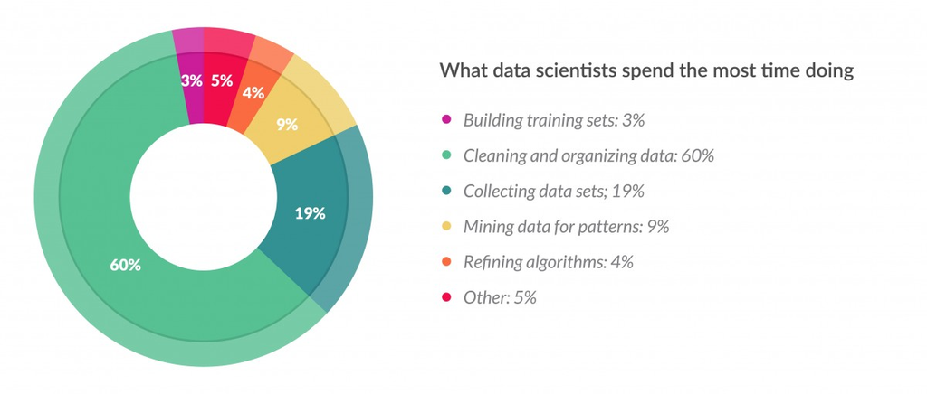

What Data Scientists spend the most time doing. Graphic courtesy of [Forbes](http://www.forbes.com/sites/gilpress/2016/03/23/data-preparation-most-time-consuming-least-enjoyable-data-science-task-survey-says/#714fcf287f75).

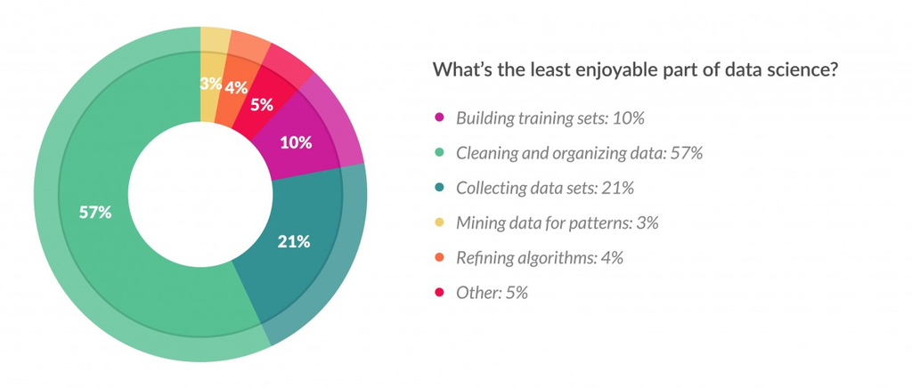

What’s the least enjoyable part of data science? Graphic courtesy of [Forbes](http://www.forbes.com/sites/gilpress/2016/03/23/data-preparation-most-time-consuming-least-enjoyable-data-science-task-survey-says/#714fcf287f75).

# 1 Munging?

*Data munging* or *data wrangling* is the process of wrestling your data into a convenient format for further analysis. It’s often said that 80% of a Data Scientist’s time is spent on data preparation. Although the precise figure may vary, this is largely true. The time spent on data preparation is probably the largest burden in a Data Science project. Training a model can proceed relatively quickly (or you can be busy with something else while the training is taking place). Data preparation, on the other hand, requires person-hours.

Fact: you will spend most of your time doing this!

Careful selection of features and creative feature engineering will have a greater effect on your project than tinkering with the parameters for the latest fancy ML algorithm.

Have a look at the [Data Wrangling Cheat Sheet](http://www.rstudio.com/wp-content/uploads/2015/02/data-wrangling-cheatsheet.pdf).

There are a number of packages which are relevant to data munging. Here’s a selection:

- [`dplyr`](https://cran.r-project.org/web/packages/dplyr/index.html)
- [`data.table`](https://cran.r-project.org/web/packages/data.table/index.html) [we won’t be looking at this, but it’s very powerful and worth knowing about!]
- [`reshape2`](https://cran.r-project.org/web/packages/reshape2/index.html)
- [`tidyr`](https://cran.r-project.org/web/packages/tidyr/index.html)

We’ll start by looking at `dplyr`.

# 2 `dplyr`

The `dplyr` package is an evolved version of the `plyr` package, incorporating most of Wickham’s latest thoughts on data manipulation It provides most of the tools that you need to wrestle your data into a format which is ready for further analysis. The most important (there are many others!) verbs in `dplyr` are

- `group` and `ungroup`,
- `select`,
- `filter`,
- `arrange`,
- `mutate` and `transmute`, and
- `summarise` (or aggregate).

These can be strung together in an essentially endless variety of combinations. Combining the results of multiple verbs is made easy with the piping operator.

Before we look at piping, it’s worth mentioning that `dplyr` uses a slightly pimped version of the data frame called a *data frame table* or `tbl_df`. We’ll be using the `iris` data for illustrative purposes and we’ll immediately convert it to a `tbl_df`.

```r
library(dplyr)
iris <- tbl_df(iris)
class(iris)
```

```
[1] "tbl_df"     "tbl"        "data.frame"
```

## 2.1 Piping with `magrittr`

The [`magrittr`](https://cran.r-project.org/web/packages/magrittr/index.html) package introduces a convenient piping syntax which is reminiscent of the `|` operator in the UNIX shell. Read the [`magrittr` vignette](https://cran.r-project.org/web/packages/magrittr/vignettes/magrittr.html) to learn all of the details. But, for the moment, the essential thing to know is that the `magrittr` pipe operator, `%>%`, makes it possible to easily take the output from one function and feed it directly into the input of another function. This means that function calls can be neatly strung together rather than nested.

```r
library(magrittr)
```

Consider, for example, the following (silly) calculation:

```r
log(sqrt(abs(cos(3 * pi / 4))))
```

Using the pipe operator the nested function calls can be replaced by a sequence of piped function calls, which are easier to read and understand.

```r
(3 * pi / 4) %>% cos %>% abs %>% sqrt %>% log
```

Confirm that the result in both cases is the same.

There are three other pipe operators, `%T>%`, `%$%` and `%<>%`, which are applied under more niche conditions. Read the documentation to find out how they work.

## 2.2 Select

The `select` operation allows you to choose a group of columns. It also makes it easy to rename columns.

### 2.2.1 Choosing Columns

Select columns by name. This also allows you to re-order and rename columns.

```r
select(iris, Species, length = Sepal.Length)
```

```
Source: local data frame [150 x 2]

   Species length
    (fctr)  (dbl)
1   setosa    5.1
2   setosa    4.9
3   setosa    4.7
4   setosa    4.6
5   setosa    5.0
6   setosa    5.4
7   setosa    4.6
8   setosa    5.0
9   setosa    4.4
10  setosa    4.9
..     ...    ...
```

There are a number of special selection functions which allow you to choose groups of columns. See `?select` for more details.

```r
select(iris, ends_with("Length"))
```

```
Source: local data frame [150 x 2]

   Sepal.Length Petal.Length
          (dbl)        (dbl)
1           5.1          1.4
2           4.9          1.4
3           4.7          1.3
4           4.6          1.5
5           5.0          1.4
6           5.4          1.7
7           4.6          1.4
8           5.0          1.5
9           4.4          1.4
10          4.9          1.5
..          ...          ...
```

A particularly cool feature of `select` is that you can specify column ranges. So, for example, to move the `Species` column to the left:

```r
iris %>% select(Species, Sepal.Length:Petal.Width)
```

```
Source: local data frame [150 x 5]

   Species Sepal.Length Sepal.Width Petal.Length Petal.Width
    (fctr)        (dbl)       (dbl)        (dbl)       (dbl)
1   setosa          5.1         3.5          1.4         0.2
2   setosa          4.9         3.0          1.4         0.2
3   setosa          4.7         3.2          1.3         0.2
4   setosa          4.6         3.1          1.5         0.2
5   setosa          5.0         3.6          1.4         0.2
6   setosa          5.4         3.9          1.7         0.4
7   setosa          4.6         3.4          1.4         0.3
8   setosa          5.0         3.4          1.5         0.2
9   setosa          4.4         2.9          1.4         0.2
10  setosa          4.9         3.1          1.5         0.1
..     ...          ...         ...          ...         ...
```

### 2.2.2 Dropping and Renaming Columns

You can simply drop the columns that you don’t need. This syntax should not be unfamiliar by now. It can also be used in conjunction with the special selection functions.

```r
select(iris, -Species)
```

```
Source: local data frame [150 x 4]

   Sepal.Length Sepal.Width Petal.Length Petal.Width
          (dbl)       (dbl)        (dbl)       (dbl)
1           5.1         3.5          1.4         0.2
2           4.9         3.0          1.4         0.2
3           4.7         3.2          1.3         0.2
4           4.6         3.1          1.5         0.2
5           5.0         3.6          1.4         0.2
6           5.4         3.9          1.7         0.4
7           4.6         3.4          1.4         0.3
8           5.0         3.4          1.5         0.2
9           4.4         2.9          1.4         0.2
10          4.9         3.1          1.5         0.1
..          ...         ...          ...         ...
```

Use `rename` to change the name of columns without changing the number of columns.

```r
rename(iris, type = Species)
```

```
Source: local data frame [150 x 5]

   Sepal.Length Sepal.Width Petal.Length Petal.Width   type
          (dbl)       (dbl)        (dbl)       (dbl) (fctr)
1           5.1         3.5          1.4         0.2 setosa
2           4.9         3.0          1.4         0.2 setosa
3           4.7         3.2          1.3         0.2 setosa
4           4.6         3.1          1.5         0.2 setosa
5           5.0         3.6          1.4         0.2 setosa
6           5.4         3.9          1.7         0.4 setosa
7           4.6         3.4          1.4         0.3 setosa
8           5.0         3.4          1.5         0.2 setosa
9           4.4         2.9          1.4         0.2 setosa
10          4.9         3.1          1.5         0.1 setosa
..          ...         ...          ...         ...    ...
```

## 2.3 Filtering

You’ll often want to extract only those rows which satisfy a particular criterion. Do this with `filter`, which is similar to `subset()` from base R.

```r
iris %>% filter(Petal.Length < 2.5 & Sepal.Length > 5.0)
```

```
Source: local data frame [22 x 5]

   Sepal.Length Sepal.Width Petal.Length Petal.Width Species
          (dbl)       (dbl)        (dbl)       (dbl)  (fctr)
1           5.1         3.5          1.4         0.2  setosa
2           5.4         3.9          1.7         0.4  setosa
3           5.4         3.7          1.5         0.2  setosa
4           5.8         4.0          1.2         0.2  setosa
5           5.7         4.4          1.5         0.4  setosa
6           5.4         3.9          1.3         0.4  setosa
7           5.1         3.5          1.4         0.3  setosa
8           5.7         3.8          1.7         0.3  setosa
9           5.1         3.8          1.5         0.3  setosa
10          5.4         3.4          1.7         0.2  setosa
..          ...         ...          ...         ...     ...
```

## 2.4 Sort

Sorting your data (ascending or descending) is a snap with `arrange`.

```r
iris %>% arrange(Sepal.Length)
```

```
Source: local data frame [150 x 5]

   Sepal.Length Sepal.Width Petal.Length Petal.Width Species
          (dbl)       (dbl)        (dbl)       (dbl)  (fctr)
1           4.3         3.0          1.1         0.1  setosa
2           4.4         2.9          1.4         0.2  setosa
3           4.4         3.0          1.3         0.2  setosa
4           4.4         3.2          1.3         0.2  setosa
5           4.5         2.3          1.3         0.3  setosa
6           4.6         3.1          1.5         0.2  setosa
7           4.6         3.4          1.4         0.3  setosa
8           4.6         3.6          1.0         0.2  setosa
9           4.6         3.2          1.4         0.2  setosa
10          4.7         3.2          1.3         0.2  setosa
..          ...         ...          ...         ...     ...
```

You can also sort on multiple columns.

```r
iris %>% arrange(Sepal.Length, desc(Sepal.Width))
```

```
Source: local data frame [150 x 5]

   Sepal.Length Sepal.Width Petal.Length Petal.Width Species
          (dbl)       (dbl)        (dbl)       (dbl)  (fctr)
1           4.3         3.0          1.1         0.1  setosa
2           4.4         3.2          1.3         0.2  setosa
3           4.4         3.0          1.3         0.2  setosa
4           4.4         2.9          1.4         0.2  setosa
5           4.5         2.3          1.3         0.3  setosa
6           4.6         3.6          1.0         0.2  setosa
7           4.6         3.4          1.4         0.3  setosa
8           4.6         3.2          1.4         0.2  setosa
9           4.6         3.1          1.5         0.2  setosa
10          4.7         3.2          1.3         0.2  setosa
..          ...         ...          ...         ...     ...
```

## 2.5 Mutate

There are two operations for changing or adding columns:

- `mutate`: adds new columns or changes existing columns; and
- `transmute`: drops existing columns and retains only new columns.

The `transform()` function in base R does essentially the same thing as `mutate`, but is less flexible: you can’t refer to the new variables that you’ve just created.

```r
iris %>% mutate(Sepal.Ratio = Sepal.Length / Sepal.Width)
```

```
Source: local data frame [150 x 6]

   Sepal.Length Sepal.Width Petal.Length Petal.Width Species Sepal.Ratio
          (dbl)       (dbl)        (dbl)       (dbl)  (fctr)       (dbl)
1           5.1         3.5          1.4         0.2  setosa      1.4571
2           4.9         3.0          1.4         0.2  setosa      1.6333
3           4.7         3.2          1.3         0.2  setosa      1.4688
4           4.6         3.1          1.5         0.2  setosa      1.4839
5           5.0         3.6          1.4         0.2  setosa      1.3889
6           5.4         3.9          1.7         0.4  setosa      1.3846
7           4.6         3.4          1.4         0.3  setosa      1.3529
8           5.0         3.4          1.5         0.2  setosa      1.4706
9           4.4         2.9          1.4         0.2  setosa      1.5172
10          4.9         3.1          1.5         0.1  setosa      1.5806
..          ...         ...          ...         ...     ...         ...
```

```r
iris %>% transmute(Sepal.Ratio = Sepal.Length / Sepal.Width)
```

```
Source: local data frame [150 x 1]

   Sepal.Ratio
         (dbl)
1       1.4571
2       1.6333
3       1.4688
4       1.4839
5       1.3889
6       1.3846
7       1.3529
8       1.4706
9       1.5172
10      1.5806
..         ...
```

Useful functions to apply: * arithmetic operations; * modular arithmetic operations (`%/%` and `%%`); * comparison operators; * `lead()` and `lag()`; * cumulative (see `?cumsum`) and rolling (check out the `RcppRoll` package) functions

## 2.6 Summarise

Cast your mind to aggregation functions in SQL where you needed to supply a `GROUP BY` clause. The same applies with `summarise` in `dplyr`.

```r
iris %>% group_by(Species) %>% summarise(
  max = max(Sepal.Length), min = min(Sepal.Length), avg = mean(Sepal.Length)
)
```

```
Source: local data frame [3 x 4]

     Species   max   min   avg
      (fctr) (dbl) (dbl) (dbl)
1     setosa   5.8   4.3 5.006
2 versicolor   7.0   4.9 5.936
3  virginica   7.9   4.9 6.588
```

To proceed with normal operations after aggregation you should first use `ungroup`.

The count function, `n()`, is a convenient way to get the number of members in each group.

## 2.7 Chaining

The true power of `dplyr` emerges when you chain all of the above operations together.

```r
iris %>% group_by(Species) %>% summarise(
  max = max(Sepal.Length), min = min(Sepal.Length), avg = mean(Sepal.Length)
) %>% mutate(range = max - min) %>% filter(range < 3) %>% select(Species, avg)
```

```
Source: local data frame [2 x 2]

     Species   avg
      (fctr) (dbl)
1     setosa 5.006
2 versicolor 5.936
```

# 3 Tidy Data

The term “tidy data” comes from (you’ll never guess it…) Hadley Wickham.

> Tidy datasets are easy to manipulate, model and visualize, and have a specific structure: each variable is a column, each observation is a row, and each type of observational unit is a table.Wickham (2014)

Data which are not “tidy” are “messy”. A messy format is not all bad: data from an experiment with a [fully crossed design](https://en.wikipedia.org/wiki/Factorial_experiment) are efficiently stored in a messy format. However, for the purposes of further analysis, it’s tidy data FTW.

The data below are in wide format. Each variable is in a separate column and each observation is a row, so these data are also tidy.

```
   Name Gender Age Height
1 Alice      F  23  163.1
2   Bob      M  21  187.0
3 Carol      F  19  190.1
4  Dave      M  20  178.4
```

The data above can be transformed into long (or “narrow”) format where there is one or more identifier column(s), followed by a column with variable names and finally a column with the variable values. Long data work well with `ggplot2`. In long format each observation is spread across multiple rows: this is messy data.

```
   Name variable value
1 Alice      Age  23.0
2   Bob      Age  21.0
3 Carol      Age  19.0
4  Dave      Age  20.0
5 Alice   Height 163.1
6   Bob   Height 187.0
7 Carol   Height 190.1
8  Dave   Height 178.4
```

Values for one variable can also be spread across multiple columns. Again, these are messy data.

```
   Name     F     M
1 Alice 163.1    NA
2   Bob    NA 187.0
3 Carol 190.1    NA
4  Dave    NA 178.4
```

As you can see above, wide data are not necessarily messy. Tidy and wide is great. Messy is not cool.

## 3.1 `reshape2`

The `reshape2` package can be used to easily transform between wide and long format. To illustrate these transformations we’ll be working with data for the total number of births in Denmark broken down by gender and year.

```r
births
```

```
  gender  2000  2001  2002  2003  2004  2005  2006  2007  2008  2009
1      m 34489 33649 32996 33210 33077 32827 33404 32815 33531 32261
2      f 32592 31801 31153 31472 31532 31455 31580 31267 31507 30557
```

Are these data tidy? Unfortunately not. Is each variable a column? No (the year is spread across multiple columns). Is each observation a row? No (the observations are broken down across rows and columns). These data are wide but messy.

As mentioned above, further analysis on messy data can be inconvenient. For example, how would you calculate the average number of births broken down by gender?

```r
rowSums(births[, -1]) / (ncol(births) - 1)
```

```
[1] 33226 31492
```

Not too difficult, but ugly and opaque.

### 3.1.1 Melting

Converting these data to tidy format is easy with the `reshape2` package.

```r
library(reshape2)
```

There are two main functions in `reshape2`, `melt()` and `cast()`, which are essentially inverses of each other. While `melt()` transforms data from wide to long format, `cast()` does the opposite.

```r
births.tidy <- melt(births, variable.name = "year", value.name = "births")
head(births.tidy)
```

```
  gender year births
1      m 2000  34489
2      f 2000  32592
3      m 2001  33649
4      f 2001  31801
5      m 2002  32996
6      f 2002  31153
```

Let’s calculate the gender averages again.

```r
births.tidy %>% group_by(gender) %>% summarise(avg = mean(births))
```

```
Source: local data frame [2 x 2]

  gender   avg
  (fctr) (dbl)
1      m 33226
2      f 31492
```

Same result as above but much simpler and more transparent. How beautiful is `dplyr`?

### 3.1.2 Casting

Although tidy data are ideal for analytical purposes, sometimes you will need to transform your beautiful tidy data into a messy format. This is often called for when data are to be presented in a table.

```r
dcast(births.tidy, year ~ gender, value.var = "births")
```

```
   year     m     f
1  2000 34489 32592
2  2001 33649 31801
3  2002 32996 31153
4  2003 33210 31472
5  2004 33077 31532
6  2005 32827 31455
7  2006 33404 31580
8  2007 32815 31267
9  2008 33531 31507
10 2009 32261 30557
```

```r
dcast(births.tidy, gender ~ year)
```

```
  gender  2000  2001  2002  2003  2004  2005  2006  2007  2008  2009
1      m 34489 33649 32996 33210 33077 32827 33404 32815 33531 32261
2      f 32592 31801 31153 31472 31532 31455 31580 31267 31507 30557
```

Sometimes there are multiple records contributing to the values in the messy data. The aggregation function which is applied in this case can be specified with the `fun.aggregate` argument to `dcast()`.

## 3.2 `tidyr`

```r
library(tidyr)
```

These are the important verbs in `tidyr`: `gather` and `spread`.

### 3.2.1 Gathering

In `tidyr` the `gather` operation fulfils the same purpose as `melt()`.

```r
births.tidy <- gather(births, year, births, -gender)
```

### 3.2.2 Spreading

Similarly, the `tidyr` equivalent to `dcast()` is `spread`.

```r
spread(births.tidy, gender, births)
```

```
   year     m     f
1  2000 34489 32592
2  2001 33649 31801
3  2002 32996 31153
4  2003 33210 31472
5  2004 33077 31532
6  2005 32827 31455
7  2006 33404 31580
8  2007 32815 31267
9  2008 33531 31507
10 2009 32261 30557
```

```r
spread(births.tidy, year, births)
```

```
  gender  2000  2001  2002  2003  2004  2005  2006  2007  2008  2009
1      m 34489 33649 32996 33210 33077 32827 33404 32815 33531 32261
2      f 32592 31801 31153 31472 31532 31455 31580 31267 31507 30557
```

# 4 Exercises

1. Mutate the `airquality` data to include the ratios of Ozone to Wind and Solar to Temp. Display a summary of the results by reporting the min, max, mean, and standard deviation of those ratios.
2. Use the script below to do the following:
- convert `Gross` to a numerical data type;
- summarise by reporting min, max, and mean `Gross` grouped by `Genre`;
- repeat the last item but for rating (`MPAA`) rather than `Gross`; and
- report any interesting findings.

```r
library(rvest)

movies = read_html("http://www.the-numbers.com/market/2015/top-grossing-movies")
movies.table = numbers %>% html_nodes("table") %>% .[[1]] %>% html_table(fill = TRUE)
movies.table <- na.omit(movies.table)
summary(movies.table)
names(movies.table)[7:8] <- c("Gross", "TicketsSold")
```

3. Consider the data below.

```
       Race    Sex   Eye Height
1     White   Male Brown  163.5
2     White Female Brown  173.1
3     Black   Male Brown  178.9
4     White Female Green  176.5
5     Black Female Brown  182.9
6     Asian   Male  Blue  174.7
7  Hispanic Female  Blue  180.1
8     White Female  Blue  185.6
9     White   Male Brown  168.7
10    White Female Green  163.0
11    White   Male  Blue  175.7
12 Hispanic   Male Green  173.0
```

Transform the data into the following format which gives the count of the number of records broken down by race, sex and eye colour.

```
      Race    Sex Brown Blue Green
1    White   Male     2    1     0
2    White Female     1    1     2
3 Hispanic   Male     0    0     1
4 Hispanic Female     0    1     0
5    Black   Male     1    0     0
6    Black Female     1    0     0
7    Asian   Male     0    1     0
```

Transform the data into the following format which gives the average height broken down by race, sex and eye colour.

```
     Sex   Eye  White Hispanic Black Asian
1   Male Brown 166.10      NaN 178.9   NaN
2   Male  Blue 175.70      NaN   NaN 174.7
3   Male Green    NaN    173.0   NaN   NaN
4 Female Brown 173.10      NaN 182.9   NaN
5 Female  Blue 185.60    180.1   NaN   NaN
6 Female Green 169.75      NaN   NaN   NaN
```

# Resources

Wickham, Hadley. 2011. “The Split-Apply-Combine Strategy for Data.” *Journal of Statistical Software* 40 (1). doi:10.18637/jss.v040.i01.

———. 2014. “Tidy Data.” *Journal of Statistical Software* 59 (10). doi:10.18637/jss.v059.i10.